# McDonalds vs BK DSC520 Final Project

Shaquiel Pashtunyar

2022-08-11

## The American Fast Food Burger

Burgers are an American tradition, its part of our culture. Over the last century we have not only seen the rise of the burger, but fast food chains that are bringing this delicacy worldwide. The two largest burger chains in America are McDonald with their golden arches, and Burger King and its crown. We can even see their global dominance and reach, with their competition known as the biggest fast food brand off. With that being said, both chains have iconic meals recognizable anywhere you go. McDonald has the Big Mac and Burger King (BK) has the Whooper as their trademarked meals.

[figure not shown]

McDonalds vs BK Global Presence(Heat Map)

## The Health Dilemma

Both of the fast food chains, while convenient and providing great bargains for food, are known to not be the healthiest. One question to ask is which of the two have a healthier menu. Comparing Burgers and Fries, can we identify which of the two is better for you. Another question is since these restaurants are global chains, do the menus in other countries have healthier options than those that are within America? In order to solve these questions we will be pull data from the nutritional fact tables of both chains, as well as the McDonald chain in India to make some comparisons. We will be comparing the composition of their key items, looking at the calories, carbs, sodium and fats, and hopefully identifying any trends leading us to the healthier fast food option!

## Analysis

The first thing necessary is to combine the data sets from McDonald America, McDonald India, and BK. With One data set we have all the data we need to make our comparisons. We have variables like calories, fat content, cholesterol, sodium, carbs, sugars, and protein for each of the items. We also have an identifier for which menu each item came from. A sample of the data set looks like this.

```
##         Chain                                Item               Type
## 1 Burger King                    Whopper Sandwich Whopper Sandwiches
## 2 Burger King        Whopper Sandwich with Cheese Whopper Sandwiches
## 3 Burger King     Bacon & Cheese Whopper Sandwich Whopper Sandwiches
## 4 Burger King             Double Whopper Sandwich Whopper Sandwiches
## 5 Burger King Double Whopper Sandwich with Cheese Whopper Sandwiches
## 6 Burger King             Triple Whopper Sandwich Whopper Sandwiches
##   Serving.Size.g Calories Total.Fat.g Saturated.Fat.g Trans.Fat.g Chol.mg
## 1            270      660          40              12           1       5
## 2            292      740          46              16           2     115
## 3            303      790          51              17           2     125
## 4            354      900          58              20           3     175
## 5            377      980          64              24           3     195
## 6            438     1130          75              28           4     255
##   Sodium.mg Total.Carb.g Total.Sugar.g Protein.g
## 1        90          980             2        11
## 2      1340           50            11        32
## 3      1560           50            11        35
## 4      1050           49            11        48
## 5      1410           50            11        52
## 6      1120           49            11        67
```

Now we can start splitting the data set into smaller samples. The first to tackle is the iconic burger battle of the Burger King Whooper and the McDonald Big Mac/Double Quarter Pounder/and Big and Tasty. The Whooper comes in three sizes so we will compare all of them to the McDonald line up.

From here we can see that McDonald’s has fewer calories on average than BK items.

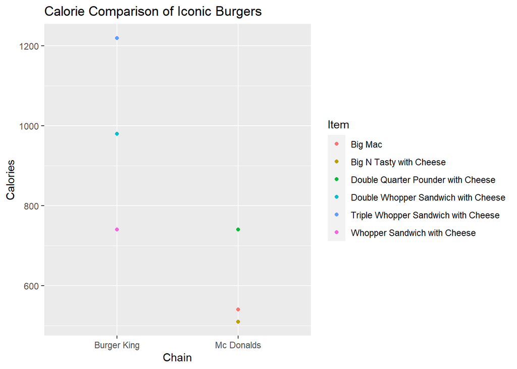

We also see a reduction of the Fats and Serving size of McDonald items in Comparison.

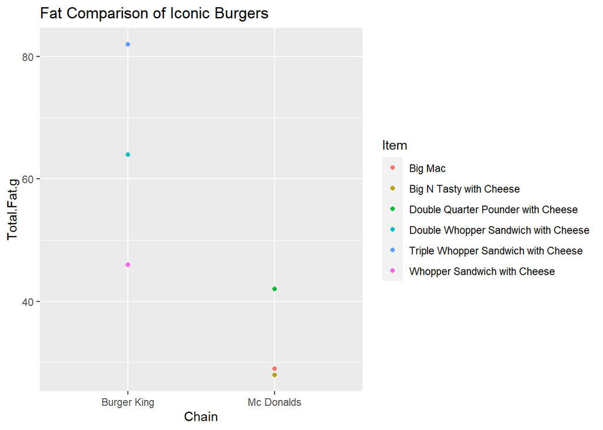

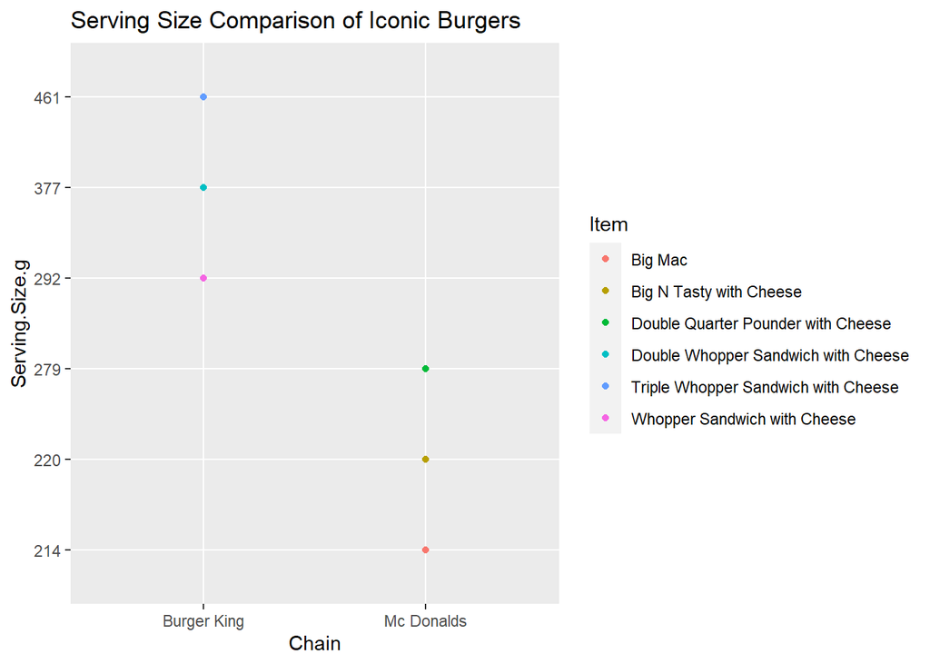

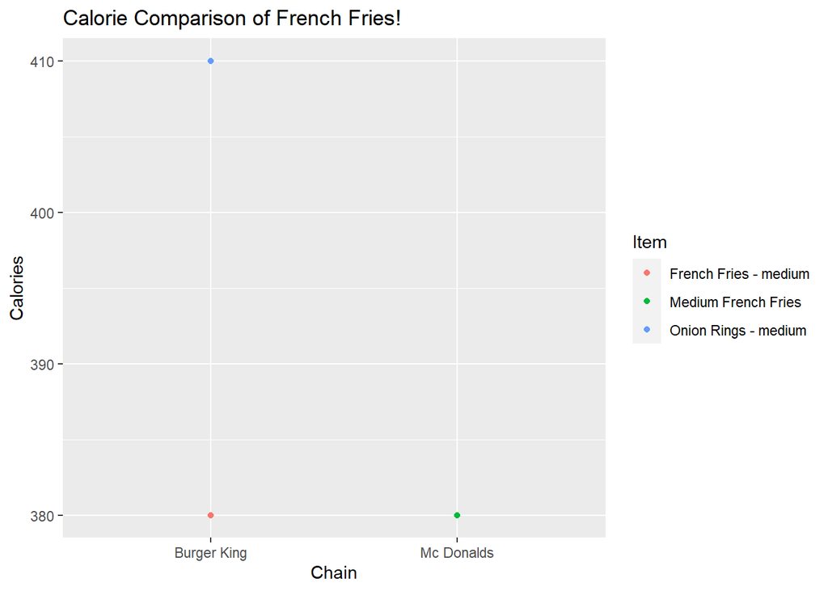

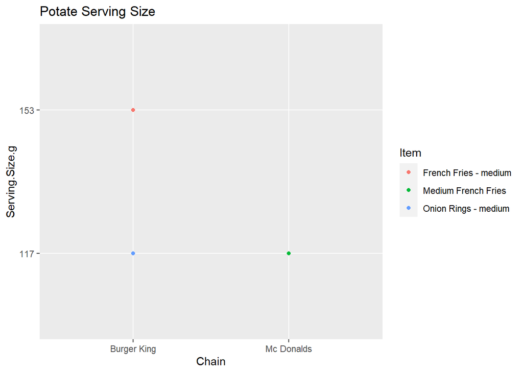

So far in our analysis, we are noticing with the two menu items that McDonalds is slightly healthier than BK in America. Both of these companies are international franchises with diverse menus across the world. Lets take a second to compare the menu of India’s McDonald vs Americas to see if there are any trends.

India doesn’t typically have as much meat on the menu, so we have hand selected a few items for comparison. What we can see from the small selection is that India’s burgers are less calories than Americas.

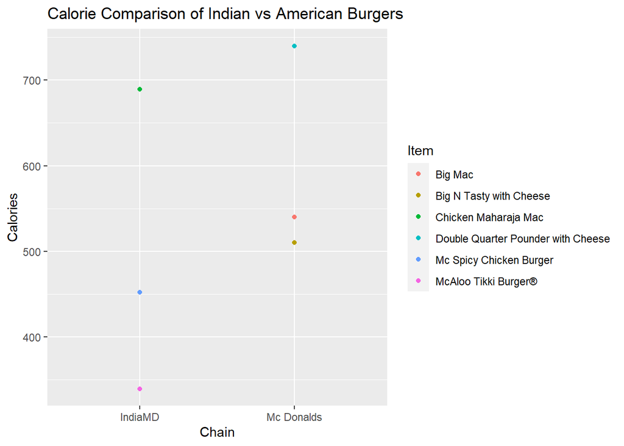

We also see the same the serving size and fat content being lower in India than America.

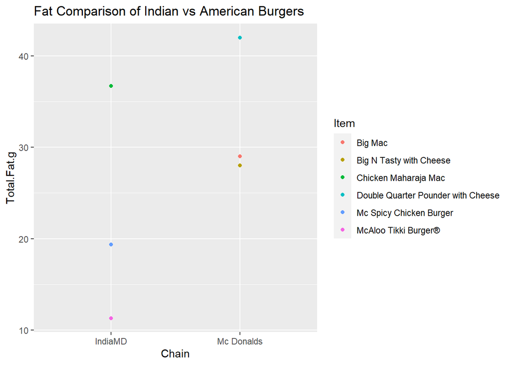

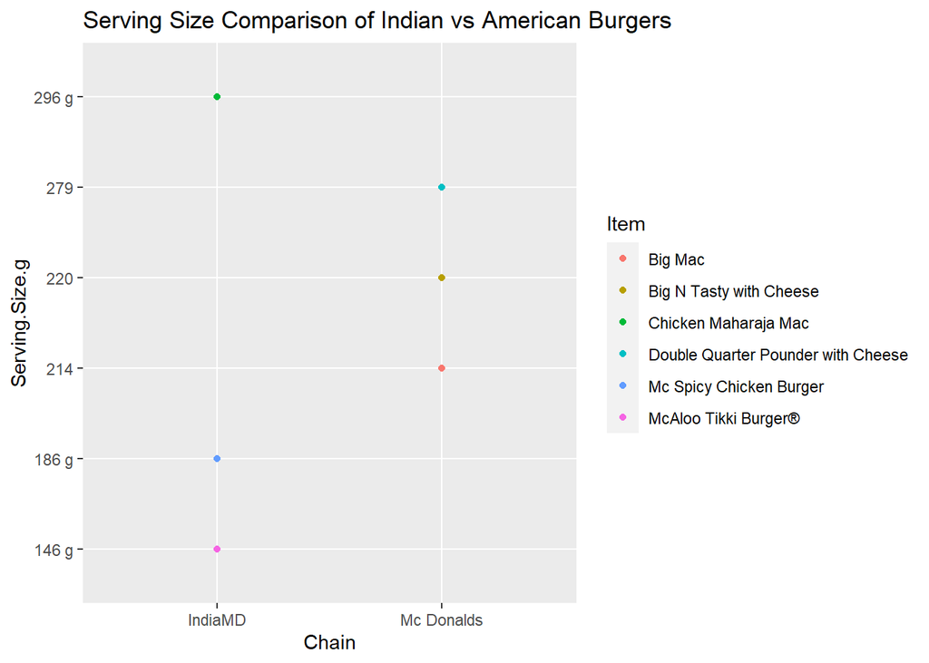

One more comparison between the two would be the french fries, here we would expect India and America to be the same size since its the same item. India also serves potatoes as a side.

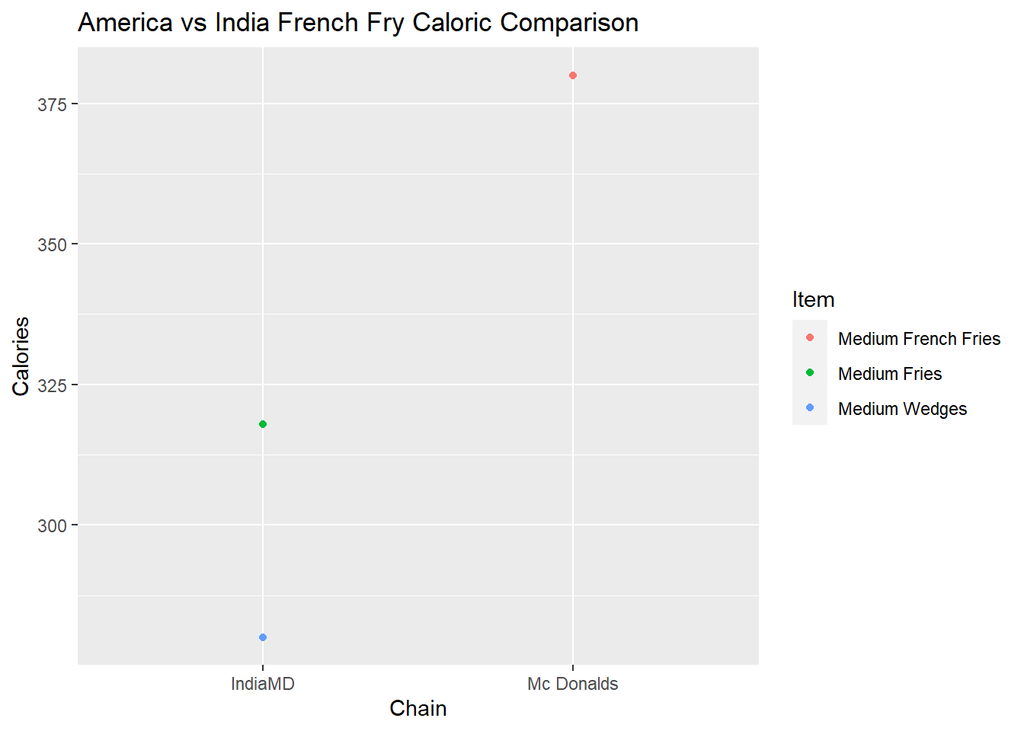

[figure not shown]

[figure not shown]

## Analysis Summary 1

So far we have compared the iconic burgers of BK, McDonald America, and McDonald India. We have seen that BK has the most calories per serving in their meals. We have also seen that Indian Mcdonalds tends to have smaller serving sizes than its American counter part for the same item. Now that we have seen 1 to 1 comparisons, we can start looking at larger data sets to see if any of the trends hold true.

## Menu Comparison

One analysis from our initial findings was that India MD was the healthiest. The issue with this study is that we looked at a small sample size. Without taking the entire sandwich lineup into consideration, it is hard to say if one is actually healthier than the other. To solve this, we can compares Whoopers, to MD Burgers, to MD Chicken Sandwiches in India, looking at all sandwich options from each menu. We know chicken is leaner than beef so that could be one explanation for the trend.

Lets take a look at the entire Sandwich and Burger menu from all three menus. Here we can see that Burger King does have several higher calorie items. The Whooper and the burgers have several entry points over 1000 calories.

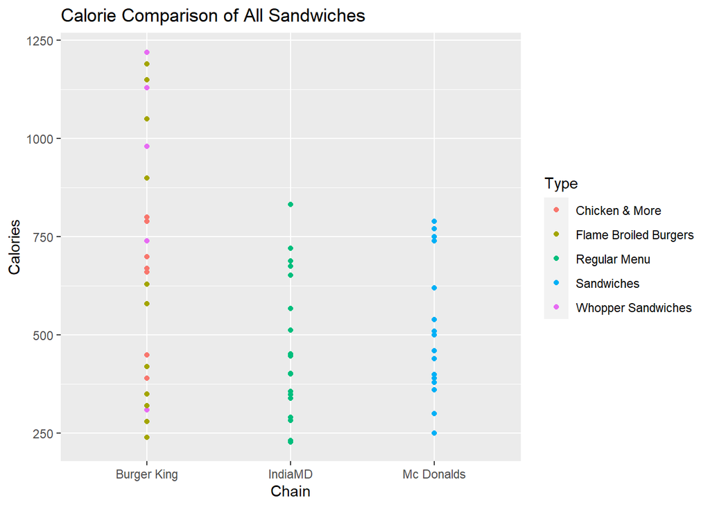

We can use a histogram chart to bin the caloric values from each of the burgers. By doing this we see that India McDonald does have several low calorie burgers and sandwiches. That is not to say that McDonalds America and Burger King don’t also have low calorie options, but we do see their menus populated with higher caloric items.

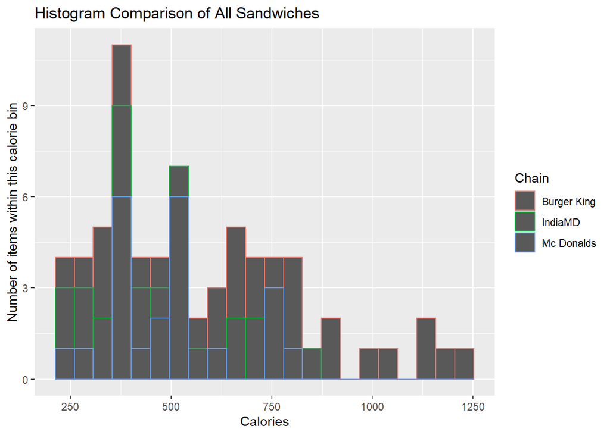

One item of interest is the fat content of the burgers. Knowing that fast food is typically on the unhealthier side, we can see if there is a correlation between the fat content and the calories of each of the menu items at each chain.

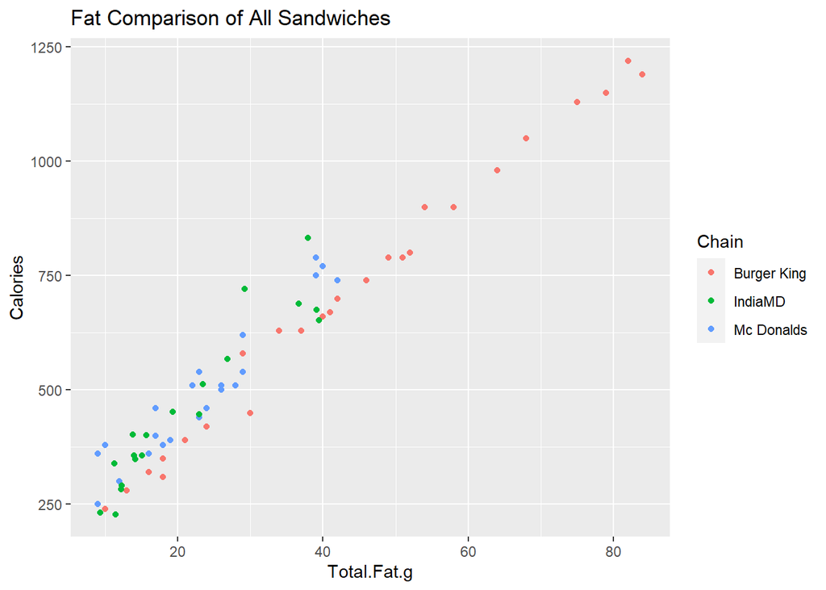

We see that Burger king has the highest fat content, and it has a a clear correlation between fat content and calories. We can dig deeper into this by looking at a smooth line plot

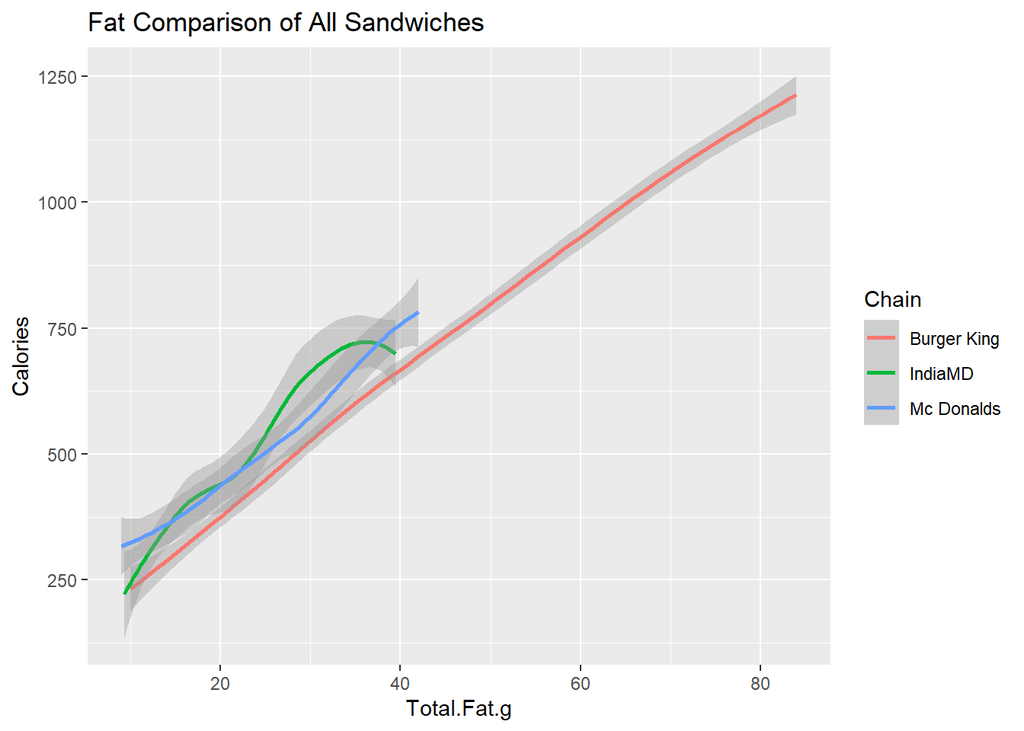

The line plot shows an extremely linear tend. We can use the correlation coefficient to see just how correlated the two are. We see and 0.97 correlation showing that the fat content is directly correlated to the calorie content. It is clear in the BK menu, and the two Mcdonalds menu’s show a similar, and slightly less correlated trend.

```r
cor(MassBurgerCompare$Total.Fat.g, MassBurgerCompare$Calories)
```

```
## [1] 0.9748421
```

It is worthwhile to take a look at other metrics like protein, sodium, and sugar to identify if any other nutritional information should be tracked.

```r
cor(MassBurgerCompare$Protein.g, MassBurgerCompare$Calories)
```

```
## [1] 0.5290681
```

```r
cor(MassBurgerCompare$Sodium.mg, MassBurgerCompare$Calories)
```

```
## [1] 0.3565384
```

```r
cor(MassBurgerCompare$Total.Carb.g, MassBurgerCompare$Calories)
```

```
## [1] 0.3704942
```

We get values between 0.37 to 0.52 for each of these items, this tells us that there likely isn’t too much correlation for us to investigate this.

## Analysis Summary 2

In our second set of analysis, we looked at the menus of each of the chains/locations more holistically. We saw that Burger King has the least healthiest options. We also saw a correlation between the amount of fat within one of the burgers and the calorie value of the burger.

## Limitations

Some of the limitations of this study is that I didn’t look at Burger Kings menu internationally. We did see that McDonald was slightly healthier oversees, and this might also be the case for BK. We also didn’t have data for the grams of meat as an option. BK does have a higher fat content, and it would be helpful to see if this is just coming from the meat or the sauce or another source. If it is just the meat content and the protein content is also higher in BK, then it might not be as unhealthy as it appears.

Another thing we didn’t spend time looking at was the other menu options like chicken nuggets, drinks, shakes, and dessert. We could have looked for coorelation there as well, but burgers felt like the items that are more typically ordered when going to one of these chains.

# Concluding Remarks